# Project: Investigate a Dataset (TMDB Movie Data)

- Introduction
- Data Wrangling
- Exploratory Data Analysis
- Conclusions

## Introduction

This dataset contains information about 10,000 movies collected from The Movie Database (TMDb).How can we utilize this dataset to identify and predict criteria that makes a good movies and eventually increase profit.  
below are the questions i plan to answer from analysing this dataset

1. Q1 - Genres populareties top to bottom based on entire dataset?
2. Q2: Movie genres over time - Most populare Genres
3. Q3: Number of movies release by year
4. Q4: Top 10 Directors with most number of movies
5. Q5: Max and Min movies profits
6. Q6: Average profit per year
7. Q7: total profit over the years
8. Q8: top 10 movies with highest profit
9. Q9: Average movie runtime from year to year
10. Q10: Actors participated in highest number of movies
11. Q11. top production companies with highest number of movies
12. Q12: relation between vote count and vote average

```python
# import libraries

import pandas as pd
import numpy as np
import matplotlib.pyplot as plt

%matplotlib inline
```

## Data Wrangling

> In this section of the report, I will load in the data and check sample size, datatype, duplication, missing values and perform data cleanliness so the dataset is ready for analysis.

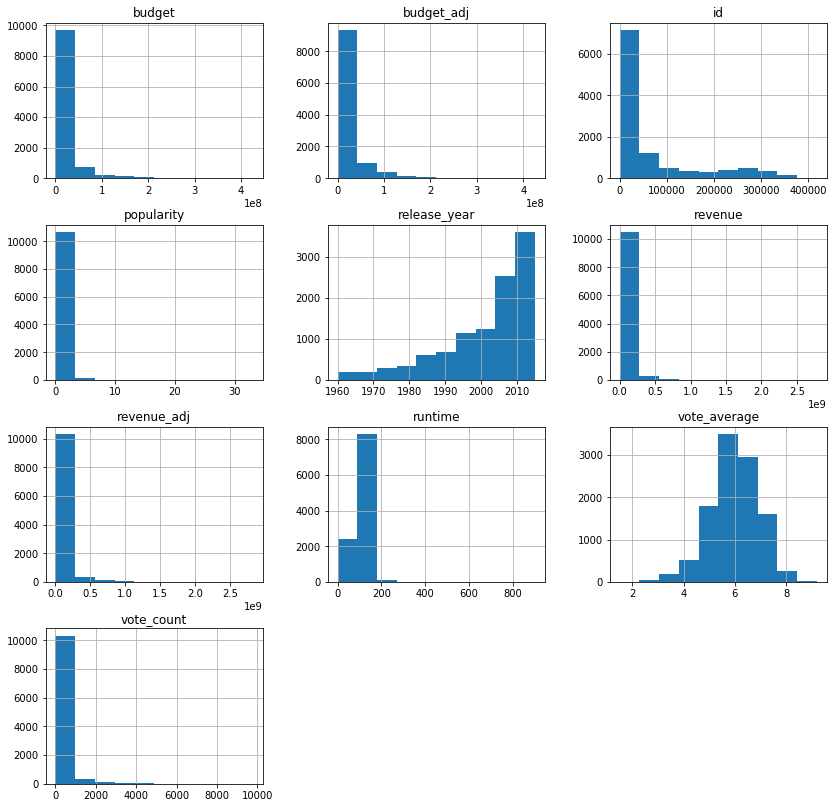

```python
# Load data and print out a few lines. Perform operations to inspect data
#   types and look for instances of missing or possibly errant data.
df=pd.read_csv('tmdb-movies.csv')
df.hist(figsize=(14,14));
```

**Findings:**

1. home_page feature is not populated most of the time, only 2936 out of 10866 total records has data (27%)
2. tagline columns has 30% of missing values
3. Both features can be considered for removal

**Data sample Datatypes**

```python
df.dtypes
```

```
id                        int64
imdb_id                  object
popularity              float64
budget                    int64
revenue                   int64
original_title           object
cast                     object
homepage                 object
director                 object
tagline                  object
keywords                 object
overview                 object
runtime                   int64
genres                   object
production_companies     object
release_date             object
vote_count                int64
vote_average            float64
release_year              int64
budget_adj              float64
revenue_adj             float64
dtype: object
```

**Findings:**  
1- release_data shoud be datetime instead of object datatype

**Features with missing values**

```python
df.isnull().sum()
```

```
id                         0
imdb_id                   10
popularity                 0
budget                     0
revenue                    0
original_title             0
cast                      76
homepage                7930
director                  44
tagline                 2824
keywords                1493
overview                   4
runtime                    0
genres                    23
production_companies    1030
release_date               0
vote_count                 0
vote_average               0
release_year               0
budget_adj                 0
revenue_adj                0
dtype: int64
```

Number of rows with at least null values in any of the columns

```python
df.isnull().any(axis=1).sum()
```

```
8874
```

**Show duplidate rows**

```python
df.duplicated().sum()
```

```
1
```

Findings: only one row is found duplicated in the dataset.

```python
df[df.duplicated(keep=False)]
```

|  | id | imdb_id | popularity | budget | revenue | original_title | cast | homepage | director | tagline | ... | overview | runtime | genres | production_companies | release_date | vote_count | vote_average | release_year | budget_adj | revenue_adj |
| --- | --- | --- | --- | --- | --- | --- | --- | --- | --- | --- | --- | --- | --- | --- | --- | --- | --- | --- | --- | --- | --- |
| 2089 | 42194 | tt0411951 | 0.60 | 30000000 | 967000 | TEKKEN | Jon Foo\|Kelly Overton\|Cary-Hiroyuki Tagawa\|Ian... | NaN | Dwight H. Little | Survival is no game | ... | In the year of 2039, after World Wars destroy ... | 92 | Crime\|Drama\|Action\|Thriller\|Science Fiction | Namco\|Light Song Films | 3/20/10 | 110 | 5.00 | 2010 | 30,000,000.00 | 967,000.00 |
| 2090 | 42194 | tt0411951 | 0.60 | 30000000 | 967000 | TEKKEN | Jon Foo\|Kelly Overton\|Cary-Hiroyuki Tagawa\|Ian... | NaN | Dwight H. Little | Survival is no game | ... | In the year of 2039, after World Wars destroy ... | 92 | Crime\|Drama\|Action\|Thriller\|Science Fiction | Namco\|Light Song Films | 3/20/10 | 110 | 5.00 | 2010 | 30,000,000.00 | 967,000.00 |

2 rows × 21 columns

```python
df.describe()
```

|  | id | popularity | budget | revenue | runtime | vote_count | vote_average | release_year | budget_adj | revenue_adj |
| --- | --- | --- | --- | --- | --- | --- | --- | --- | --- | --- |
| count | 10,866.00 | 10,866.00 | 10,866.00 | 10,866.00 | 10,866.00 | 10,866.00 | 10,866.00 | 10,866.00 | 10,866.00 | 10,866.00 |
| mean | 66,064.18 | 0.65 | 14,625,701.09 | 39,823,319.79 | 102.07 | 217.39 | 5.97 | 2,001.32 | 17,551,039.82 | 51,364,363.25 |
| std | 92,130.14 | 1.00 | 30,913,213.83 | 117,003,486.58 | 31.38 | 575.62 | 0.94 | 12.81 | 34,306,155.72 | 144,632,485.04 |
| min | 5.00 | 0.00 | 0.00 | 0.00 | 0.00 | 10.00 | 1.50 | 1,960.00 | 0.00 | 0.00 |
| 25% | 10,596.25 | 0.21 | 0.00 | 0.00 | 90.00 | 17.00 | 5.40 | 1,995.00 | 0.00 | 0.00 |
| 50% | 20,669.00 | 0.38 | 0.00 | 0.00 | 99.00 | 38.00 | 6.00 | 2,006.00 | 0.00 | 0.00 |
| 75% | 75,610.00 | 0.71 | 15,000,000.00 | 24,000,000.00 | 111.00 | 145.75 | 6.60 | 2,011.00 | 20,853,251.08 | 33,697,095.72 |
| max | 417,859.00 | 32.99 | 425,000,000.00 | 2,781,505,847.00 | 900.00 | 9,767.00 | 9.20 | 2,015.00 | 425,000,000.00 | 2,827,123,750.41 |

**Finding**

1. About 50% of budget, revenue, budget_adj * revenue_adj have a value of 0. this will have big impact on the meanvalues.
2. Obvious outliars exist for runtime, and vote_count, and possibly populariy column.

**Identifying number of features with value 0 and combinations**

```python
(df['budget_adj'] == 0).sum()
```

```
5696
```

```python
(df['revenue_adj'] == 0).sum()
```

```
6016
```

```python
(df['runtime'] == 0).sum()
```

```
31
```

```python
(df['revenue']==0).sum()
```

```
6016
```

```python
(df['budget']==0).sum()
```

```
5696
```

```python
((df['budget_adj']==0) & (df['revenue_adj']==0)).sum()
```

```
4701
```

```python
((df['runtime']==0) & (df['revenue_adj']==0)).sum()
```

```
31
```

```python
((df['budget_adj']==0) & (df['runtime']==0)).sum()
```

```
28
```

**Findings:**

1. budget_adj has the same number of missing values as budget column. smiliar case for revenue and revenue_adj
2. since budget_adj & revenue_adj cater for inflation, they should be better used for analysis.

**Check for unique values**

```python
df.nunique()
```

```
id                      10865
imdb_id                 10855
popularity              10814
budget                    557
revenue                  4702
original_title          10571
cast                    10719
homepage                 2896
director                 5067
tagline                  7997
keywords                 8804
overview                10847
runtime                   247
genres                   2039
production_companies     7445
release_date             5909
vote_count               1289
vote_average               72
release_year               56
budget_adj               2614
revenue_adj              4840
dtype: int64
```

**Findings:**

1. the original_title has 295 rows with duplicate titles, but remaining of the data is diffirent. so it's not a duplicate record (only title duplication)
2. the last 35 rows has strange characters probably used the foriegn language which got corrupted during laoding or conversion. this should not matter on the analysis but overall we lost the movies titles for those movies.

```python
titles=df.groupby('original_title').count()
titles.tail(20)
```

| original_title | id | imdb_id | popularity | budget | revenue | cast | homepage | director | tagline | keywords | overview | runtime | genres | production_companies | release_date | vote_count | vote_average | release_year | budget_adj | revenue_adj |
| --- | --- | --- | --- | --- | --- | --- | --- | --- | --- | --- | --- | --- | --- | --- | --- | --- | --- | --- | --- | --- |
| ç‰ä¸€å€‹äººå’–å•¡ | 1 | 1 | 1 | 1 | 1 | 1 | 1 | 1 | 0 | 1 | 1 | 1 | 1 | 1 | 1 | 1 | 1 | 1 | 1 | 1 |
| ç»™çˆ¸çˆ¸çš„ä¿¡ | 1 | 1 | 1 | 1 | 1 | 1 | 0 | 1 | 0 | 0 | 1 | 1 | 1 | 1 | 1 | 1 | 1 | 1 | 1 | 1 |
| è§£æ•‘å´å…ˆç”Ÿ | 1 | 1 | 1 | 1 | 1 | 1 | 0 | 1 | 0 | 0 | 1 | 1 | 1 | 0 | 1 | 1 | 1 | 1 | 1 | 1 |
| è³½å¾·å…‹Â·å·´èŠ (ä¸Š) å¤ªé™½æ—— | 1 | 1 | 1 | 1 | 1 | 1 | 0 | 1 | 1 | 0 | 1 | 1 | 1 | 1 | 1 | 1 | 1 | 1 | 1 | 1 |
| è‰‹èˆº | 1 | 1 | 1 | 1 | 1 | 1 | 0 | 1 | 0 | 0 | 1 | 1 | 1 | 0 | 1 | 1 | 1 | 1 | 1 | 1 |
| é»‘å¤ªé™½731 | 1 | 1 | 1 | 1 | 1 | 1 | 0 | 1 | 0 | 1 | 1 | 1 | 1 | 1 | 1 | 1 | 1 | 1 | 1 | 1 |
| é»‘ç¤¾ä¼š2ï¼šä»¥å’Œä¸ºè´µ | 1 | 1 | 1 | 1 | 1 | 1 | 0 | 1 | 1 | 1 | 1 | 1 | 1 | 1 | 1 | 1 | 1 | 1 | 1 | 1 |
| é€ƒå¦å¨é¾™ | 1 | 1 | 1 | 1 | 1 | 1 | 0 | 1 | 0 | 0 | 1 | 1 | 1 | 0 | 1 | 1 | 1 | 1 | 1 | 1 |
| ê³ ì‚¬ ë‘ ë²ˆì§¸ ì´ì•¼ê¸°: êµìƒì‹¤ìŠµ | 1 | 1 | 1 | 1 | 1 | 1 | 0 | 1 | 0 | 0 | 1 | 1 | 1 | 0 | 1 | 1 | 1 | 1 | 1 | 1 |
| ëª½íƒ€ì£¼ | 1 | 1 | 1 | 1 | 1 | 1 | 0 | 1 | 0 | 0 | 1 | 1 | 1 | 1 | 1 | 1 | 1 | 1 | 1 | 1 |
| ì§íŒ¨ | 1 | 1 | 1 | 1 | 1 | 1 | 0 | 1 | 0 | 1 | 1 | 1 | 1 | 1 | 1 | 1 | 1 | 1 | 1 | 1 |
| ì§‘ìœ¼ë¡œ ê°€ëŠ” ê¸¸ | 1 | 1 | 1 | 1 | 1 | 1 | 0 | 1 | 0 | 1 | 1 | 1 | 1 | 0 | 1 | 1 | 1 | 1 | 1 | 1 |
| ìºì¹˜ë¯¸ | 1 | 1 | 1 | 1 | 1 | 1 | 0 | 1 | 0 | 0 | 1 | 1 | 1 | 1 | 1 | 1 | 1 | 1 | 1 | 1 |
| ìž‘ì—…ì˜ ì •ì„ | 1 | 1 | 1 | 1 | 1 | 1 | 0 | 1 | 0 | 1 | 1 | 1 | 1 | 0 | 1 | 1 | 1 | 1 | 1 | 1 |
| ì˜í˜•ì œ | 1 | 1 | 1 | 1 | 1 | 1 | 1 | 1 | 1 | 1 | 1 | 1 | 1 | 1 | 1 | 1 | 1 | 1 | 1 | 1 |
| ì•„ê¸°ì™€ ë‚˜ | 1 | 1 | 1 | 1 | 1 | 1 | 0 | 1 | 0 | 0 | 1 | 1 | 0 | 0 | 1 | 1 | 1 | 1 | 1 | 1 |
| ì‹ ì˜ í•œ ìˆ˜ | 1 | 1 | 1 | 1 | 1 | 1 | 0 | 1 | 0 | 1 | 1 | 1 | 1 | 0 | 1 | 1 | 1 | 1 | 1 | 1 |
| í¬í™” ì†ìœ¼ë¡œ | 1 | 1 | 1 | 1 | 1 | 1 | 0 | 1 | 0 | 1 | 1 | 1 | 1 | 1 | 1 | 1 | 1 | 1 | 1 | 1 |
| í˜•ì‚¬ Duelist | 1 | 1 | 1 | 1 | 1 | 1 | 0 | 1 | 0 | 1 | 1 | 1 | 1 | 1 | 1 | 1 | 1 | 1 | 1 | 1 |
| í•˜ìš¸ë§ | 1 | 1 | 1 | 1 | 1 | 1 | 1 | 1 | 0 | 1 | 1 | 1 | 1 | 1 | 1 | 1 | 1 | 1 | 1 | 1 |

## Observations

> The followin columns are not important for the data analysis and at the same time not fully populated, better of be removed:
> 1. homepage
> 2. tagline
> 3. overview
> 4. budget - the budget_adj is better use for analysis
> 5. revenue - revenue_adj is better use for analysis

> Columns holding more than one value separated by "|" needs to be separated then joined together for comprehensive data view and analysis.
> 1. cast
> 2. director
> 3. genres
> 4. production_companies
> 5. keywords

> release_data column shoud be datetime instead of object datatype

> One duplicated row needs to be removed.

> Many of values in the following columns set to 0, for proper analysis these values need to set to mean value of the column. i will also consider dropping these values and compare results.
> 1. budget_adj
> 2. revenue_adj
> 3. budget
> 4. revenue
> 5. runtime The original_title column has some invalid characters, this will have no impact on the report since data will be assessed on other features.

> Add new column to capture profit difference betweeen revenue_adj and budget_adj

> Outliars values in
> 1. popularity value of 32
> 2. runtime of 900 minutes
> 3. vote_count of 9,767.00
> 4. revenue_adj of 2.8 Billions
> 5. budget_adj of 425 Millions

### Data Cleaning (Step one Add profit column to datafram)

#### Data Clearning - Step 1: Change floating number format to show decimals)

```python
# set pandas options to see full number
pd.options.display.float_format = '{:,.2f}'.format
# value results
df.head(1)
```

|  | id | imdb_id | popularity | budget | revenue | original_title | cast | homepage | director | tagline | ... | overview | runtime | genres | production_companies | release_date | vote_count | vote_average | release_year | budget_adj | revenue_adj |
| --- | --- | --- | --- | --- | --- | --- | --- | --- | --- | --- | --- | --- | --- | --- | --- | --- | --- | --- | --- | --- | --- |
| 0 | 135397 | tt0369610 | 32.99 | 150000000 | 1513528810 | Jurassic World | Chris Pratt\|Bryce Dallas Howard\|Irrfan Khan\|Vi... | http://www.jurassicworld.com/ | Colin Trevorrow | The park is open. | ... | Twenty-two years after the events of Jurassic ... | 124 | Action\|Adventure\|Science Fiction\|Thriller | Universal Studios\|Amblin Entertainment\|Legenda... | 6/9/15 | 5562 | 6.50 | 2015 | 137,999,939.28 | 1,392,445,892.52 |

1 rows × 21 columns

#### Data Clearning - Step 2: change dtype for release_date to datetime)

```python
df['release_date']=pd.to_datetime(df['release_date'])
df['release_date'].head(1)
```

```
0   2015-06-09
Name: release_date, dtype: datetime64[ns]
```

#### Data Clearning - Step 3: Drop unwanted columns

```python
df.drop(['budget','revenue','homepage','tagline','overview'],axis=1, inplace=True)
```

#### Data Clearning - Step1: setting option 1 dataframe df

```python
#First replace 0 with NaN
df['revenue_adj'].replace(0, np.NAN, inplace=True)
df['budget_adj'].replace(0, np.NAN, inplace=True)
df['runtime'].replace(0, np.NAN, inplace=True)

#Second update NaN with mean values
df['budget_adj'].fillna(df['budget_adj'].mean(), inplace=True)
df['revenue_adj'].fillna(df['revenue_adj'].mean(), inplace=True)
df['runtime'].fillna(df['runtime'].mean(), inplace=True)

# add new profit column
df['profit']=df['revenue_adj']-df['budget_adj']

#remove duplicates
df.drop_duplicates(inplace=True)
df.duplicated().sum()
df.info()
```

```
<class 'pandas.core.frame.DataFrame'>
Int64Index: 10865 entries, 0 to 10865
Data columns (total 17 columns):
id                      10865 non-null int64
imdb_id                 10855 non-null object
popularity              10865 non-null float64
original_title          10865 non-null object
cast                    10789 non-null object
director                10821 non-null object
keywords                9372 non-null object
runtime                 10865 non-null float64
genres                  10842 non-null object
production_companies    9835 non-null object
release_date            10865 non-null datetime64[ns]
vote_count              10865 non-null int64
vote_average            10865 non-null float64
release_year            10865 non-null int64
budget_adj              10865 non-null float64
revenue_adj             10865 non-null float64
profit                  10865 non-null float64
dtypes: datetime64[ns](1), float64(6), int64(3), object(7)
memory usage: 1.5+ MB
```

## Exploratory Data Analysis

> **Tip**: Now that you've trimmed and cleaned your data, you're ready to move on to exploration. Compute statistics and create visualizations with the goal of addressing the research questions that you posed in the Introduction section. It is recommended that you be systematic with your approach. Look at one variable at a time, and then follow it up by looking at relationships between variables.

### Q1 - Genres populareties top to bottom based on entire dataset?

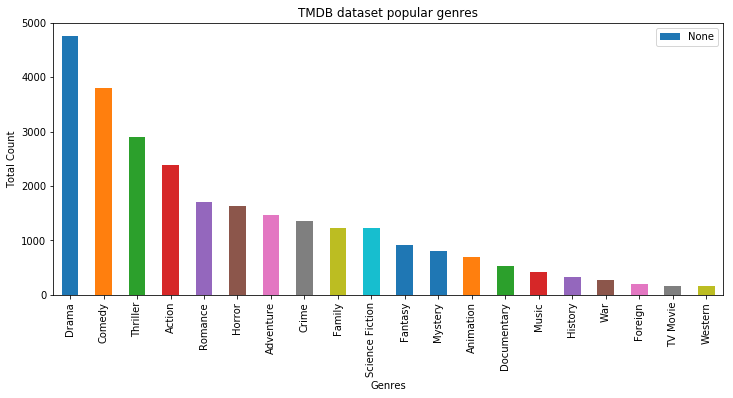

```python
# Extract all entries in genres column as one long string
data = df['genres'].str.cat(sep = '|')
# Split genres into a Pandas Series
data = pd.Series(data.split('|'))
# get Value count each genere
count = data.value_counts(ascending = False)
ax=count.plot.bar(x=count.index, y=count,figsize=(12,5), legend=True, title='TMDB dataset popular genres')
ax.set_xlabel("Genres")
ax.set_ylabel("Total Count")
plt.figure(figsize=(20,10))
```

### Q2: Movie genres over time - Most populare Genres

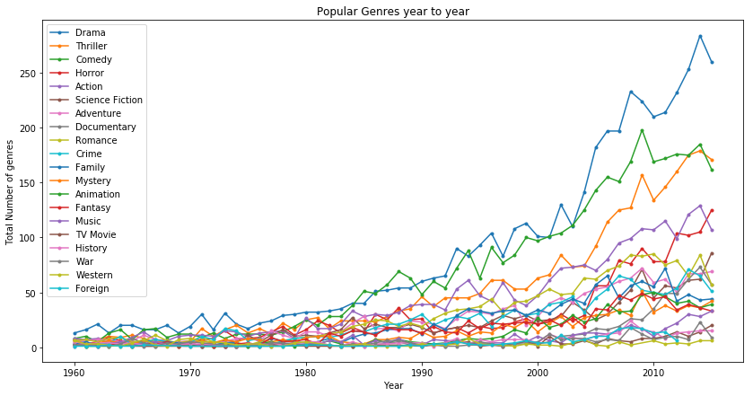

```python
year_list=[]
genres_list=[]
count_list=[]
common_genres=[]
all_data_list_index=[]
all_data_list_values=[]
all_data_list_years=[]
all_data_dict={}

def popular_genres_year(year, column_name):
    data = df[df['release_year']==year][column_name].str.cat(sep = '|')
    # Create pandas series and store the values separately
    data = pd.Series(data.split('|'))
    # Display value count in descending order
    count = data.value_counts(ascending = False)
    #all_data_list_year=[]
    all_data_list_year=np.repeat(year,len(count.index.tolist())).tolist()
    all_data_list_index.extend(count.index.tolist())
    all_data_list_values.extend(count.tolist())
    all_data_list_years.extend(all_data_list_year)
    return

years = df['release_year'].unique()
for year in years:
    popular_genres_year(year,'genres')

my_dict={'year':all_data_list_years, 'genres':all_data_list_index, 'count':all_data_list_values}

# genres_list
df_dict=pd.DataFrame(my_dict)

gens = df_dict['genres'].unique()

plt.figure(figsize=(14, 7))
plt.xlabel('Year')
plt.ylabel('Total Number of genres')
plt.title('Popular Genres year to year')
for n in gens:
    df_temp=[]
    df_temp = df_dict[df_dict['genres']==n]
    df_temp.sort_values(by=['year'], ascending=True, inplace=True)
    x_vals =df_temp['year'].tolist()
    y_vals=df_temp['count'].tolist()
    plt.plot(x_vals, y_vals, '.-', label=n)
plt.legend()
```

### Q3: Number of movies release by year

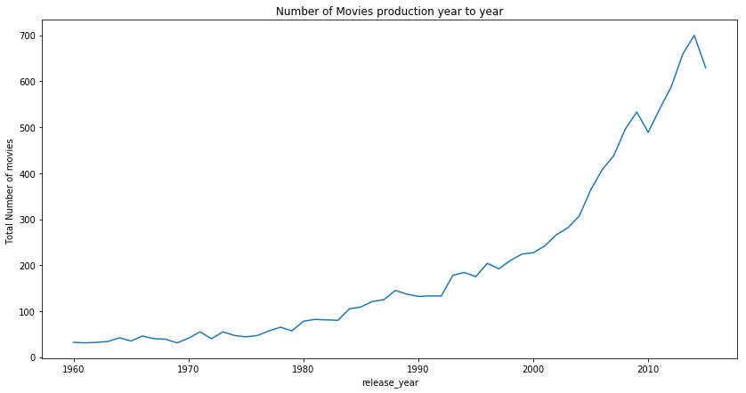

```python
plt.figure(figsize=(14, 7))
plt.xlabel(' Year ')
plt.ylabel('Total Number of movies ')
plt.title('Number of Movies production year to year')
df.groupby('release_year')['id'].count().plot()
```

```python
df.groupby('release_year')['id'].count()
```

```
release_year
1960     32
1961     31
1962     32
1963     34
1964     42
1965     35
1966     46
1967     40
1968     39
1969     31
1970     41
1971     55
1972     40
1973     55
```

[output cut: 43 more lines]

```python
directors_list = df['director'].value_counts()
directors_list[directors_list > 20].head(10)
```

```
Woody Allen          45
Clint Eastwood       34
Martin Scorsese      29
Steven Spielberg     29
Ridley Scott         23
Steven Soderbergh    22
Ron Howard           22
Joel Schumacher      21
Name: director, dtype: int64
```

## check which of the directors also is top in profit

```python
df.groupby('director')['profit'].sum().sort_values(ascending=False)[:10]
```

```
director
Steven Spielberg   13,280,831,549.61
James Cameron       6,489,495,710.14
Peter Jackson       5,874,277,821.26
George Lucas        5,844,159,207.50
Robert Zemeckis     4,520,236,846.64
Chris Columbus      4,435,946,487.26
Michael Bay         3,958,675,886.72
David Yates         3,472,619,726.15
Tim Burton          3,471,916,282.25
Ron Howard          3,327,018,018.88
Name: profit, dtype: float64
```

## Q5: Max and Min movies profits

```python
max_profit=df.iloc[df['profit'].idxmax()]
min_profit=df.iloc[df['profit'].idxmin()]
max_min = {'max':max_profit, 'min':min_profit}
df_max_min_profit=pd.DataFrame(max_min)
df_max_min_profit
```

[output not shown]

### Q6: Average profit per year

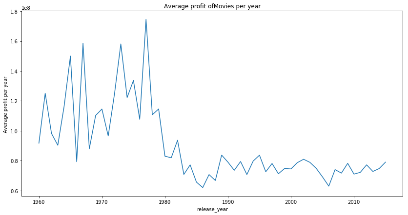

```python
plt.figure(figsize=(14, 7))
plt.xlabel(' Year ')
plt.ylabel('Average profit per year ')
plt.title('Average profit ofMovies per year')
df.groupby('release_year')['profit'].mean().plot()
```

## Q7: total profit over the years

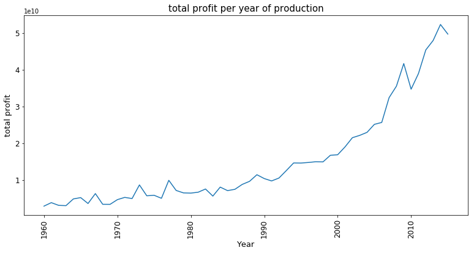

```python
profit_by_year = df.groupby('release_year')['profit'].sum()

profit_by_year.plot(kind='line', figsize=(13,6),fontsize=12)
plt.title("total profit per year of production",fontsize=15)
plt.xticks(rotation = 90)
plt.xlabel('Year',fontsize=13)
plt.ylabel("total profit",fontsize= 13)

#figure size(width, height)
plt.figure(figsize=(12,6), dpi = 130)
```

Finding: This is due to the number of movies increase

```
Text(0,0.5,'Number Of Movies')
```

[figure not shown]

```python
#make a plot which contain top 10 movies which earn highest profit.
#sort the 'Profit' column in decending order and store it in the new dataframe,
profit_df = pd.DataFrame(df['profit'].sort_values(ascending = False))
profit_df['original_title'] = df['original_title']
# limit title lengh
profit_df['original_title']=profit_df['original_title'].apply(lambda x:x[0:20])
profit_df.set_index('original_title', inplace=True)
profit_df.iloc[:20].plot.bar(figsize=(13,6),fontsize=12)
plt.title("Most Frequent Actor",fontsize=15)
plt.xticks(rotation = 90)
plt.xlabel('Actor',fontsize=13)
plt.ylabel("Number Of Movies",fontsize= 13)
```

## Q9: Average movie runtime from year to year

[figure not shown]

```python
plt.figure(figsize=(14, 7))
plt.xlabel(' Year ')
plt.ylabel('Average profit per year')
plt.title('Average profit of Movies per year')
df.groupby('release_year')['runtime'].mean().plot()
```

## Q10: Actors participated in highest number of movies

```python
# Extract all entries in actors column as one long string
data = df['cast'].str.cat(sep = '|')
# Split acrtor into a Pandas Series
data = pd.Series(data.split('|'))
# get Value count each actor
count = data.value_counts(ascending = False)
count[:10]
```

```
Robert De Niro       72
Samuel L. Jackson    71
Bruce Willis         62
Nicolas Cage         61
Michael Caine        53
Robin Williams       51
John Cusack          50
Morgan Freeman       49
John Goodman         49
Susan Sarandon       48
dtype: int64
```

```
Text(0,0.5,'Total number of movies')
```

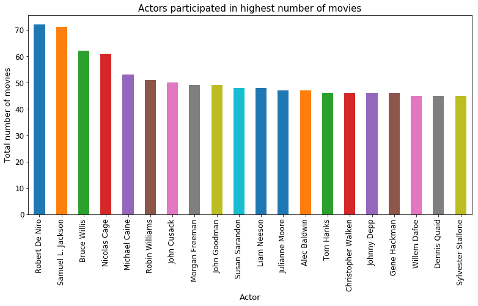

```python
# Extract all entries in actors column as one long string
data = df['cast'].str.cat(sep = '|')
# Split acrtor into a Pandas Series
data = pd.Series(data.split('|'))
# get Value count each actor
count = data.value_counts(ascending = False)

count.iloc[:20].plot.bar(figsize=(13,6),fontsize=12)
plt.title("Actors participated in highest number of movies",fontsize=15)
plt.xticks(rotation = 90)
plt.xlabel('Actor',fontsize=13)
plt.ylabel("Total number of movies",fontsize= 13)
```

## Q11. top production companies with highest number of movies

```
Text(0,0.5,'Total number of movies')
```

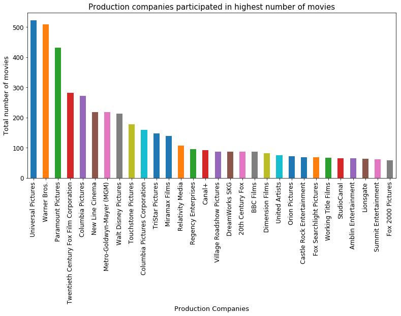

```python
# Extract all entries in production company column as one long string
data = df['production_companies'].str.cat(sep = '|')
# Split production company name into a Pandas Series
data = pd.Series(data.split('|'))
# get Value count each production company
count = data.value_counts(ascending = False)

count.iloc[:30].plot.bar(figsize=(13,6),fontsize=12)
plt.title("Production companies participated in highest number of movies",fontsize=15)
plt.xticks(rotation = 90)
plt.xlabel('Production Companies',fontsize=13)
plt.ylabel("Total number of movies",fontsize= 13)
```

## Q12: relation between various features in the dataset

```python
df_votes=df[['vote_count','vote_average']]#.describe['vote_count','vote_average'].describe()
df_votes.describe()
```

|  | vote_count | vote_average |
| --- | --- | --- |
| count | 10,865.00 | 10,865.00 |
| mean | 217.40 | 5.98 |
| std | 575.64 | 0.94 |
| min | 10.00 | 1.50 |
| 25% | 17.00 | 5.40 |
| 50% | 38.00 | 6.00 |
| 75% | 146.00 | 6.60 |
| max | 9,767.00 | 9.20 |

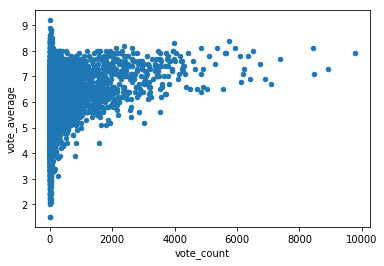

```python
df_votes.plot(x='vote_count', y='vote_average', kind='scatter');
```

```python
df_votes['vote_count'].corr(df_votes['vote_average'])
```

```
0.25381786600245509
```

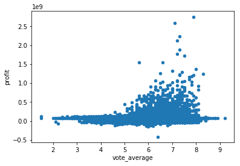

```python
df_avg_votes_profit=df[['vote_average','profit']]
df_avg_votes_profit.describe()
df_avg_votes_profit.plot(x='vote_average', y='profit', kind='scatter');
```

```python
df_avg_votes_profit['vote_average'].corr(df_avg_votes_profit['profit'])
```

```
0.1351776672548729
```

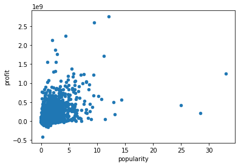

```python
df_popularity_profit=df[['popularity','profit']]
df_popularity_profit.describe()
df_popularity_profit.plot(x='popularity', y='profit', kind='scatter');
```

```python
df_popularity_profit['popularity'].corr(df_popularity_profit['profit'])
```

```
0.46644745169735652
```

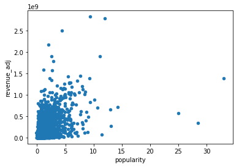

```python
df_popularity_revenue=df[['popularity','revenue_adj']]
df_popularity_revenue.describe()
df_popularity_revenue.plot(x='popularity', y='revenue_adj', kind='scatter');
```

```python
df_popularity_revenue['popularity'].corr(df_popularity_revenue['revenue_adj'])
```

```
0.50904178528260613
```

there dones't seem to be a big relationship between votes and profit, better correlation between popularity and profit but not very big and can't be used as an indicator

## Limitations:

1. there are huge number of movies with missing data specially in the budget and revenue columns.
2. there are not clear correlation or indication to what features are the secret to produce a high profitable movie